# Chapter 3 Solutions

Amanda P

1/14/2018

# 3.2.1 Exercises

1. What geoms would you use to draw each of the following named plots?
- Scatterplot: geom_point
- Line chart: geom_line
- Histogram: geom_histogram
- Bar chart: geom_bar
- Pie chart: There is no pie chart geom. You need to create a bar chart and then change to polar coordinates. More on this in Chapter 7.
2. What’s the difference between `geom_path()` and `geom_polygon()`? What the difference between `geom_path()` and `geom_line()`?
- geom_path: Draws lines between points starting with the first data point (i.e. row) and ending with the last data point (i.e. row)
- geom_polygon: Draws lines between points. The start and end points are connected and the inside color is filled. The group determines which cases are connected.
- geom_line: Draws lines between points starting with the smallest x coordinate to the largest x coordinate.
3. What low-level geoms are used to draw `geom_smooth()`? What about `geom_boxplot` and `geom_violin`?

Description from Jake Kaupp: “You can check this out by investigating the `geom_smooth` call, which shows the call accessing the geom `GeomSmooth`. If you then look at `GeomSmooth` you get shown a list and the fact that it is a `ggproto` object. This is where you run into the fact that `ggplot2` runs on an object-oriented paradigm.

You can access the pieces of the object via `$`, e.g. `GeomSmooth$draw_group` If you make that call you can see that `geom_smooth` uses `GeomLine` and `GeomRibbon`. A lot of background reading on the `ggproto` system can be found in https://cran.r-project.org/web/packages/ggplot2/vignettes/extending-ggplot2.html You can follow the same paths, or just call `GeomBoxplot$draw_group` or `GeomViolin$draw_group` to find out what geoms those calls use."

- `geom_smooth`: GeomLine, GeomRibbon
- `geom_boxplot`: GeomSegment, GeomCrossbar, GeomPoint
- `geom_violin`: GeomPolygon, GeomPath

# 3.5.5 Exercises

1. Draw a boxplot of `hwy` for each value of `cyl`, without turning `cyl` into a factor. What extra aesthetic do you need to set?

You need to set the group aesthetic:

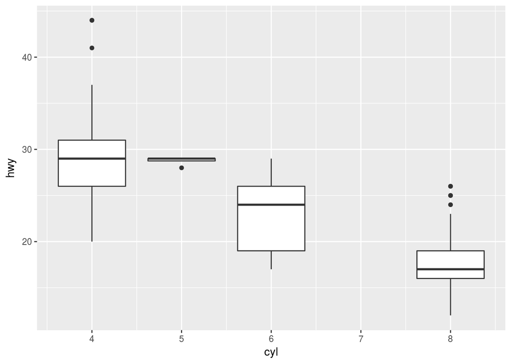

```r
ggplot(mpg,aes(cyl,hwy,group=cyl)) + geom_boxplot()
```

2. Modify the following plot so that you get one boxplot per integer value of `displ`: `ggplot(mpg, aes(displ, cty)) + geom_boxplot()`

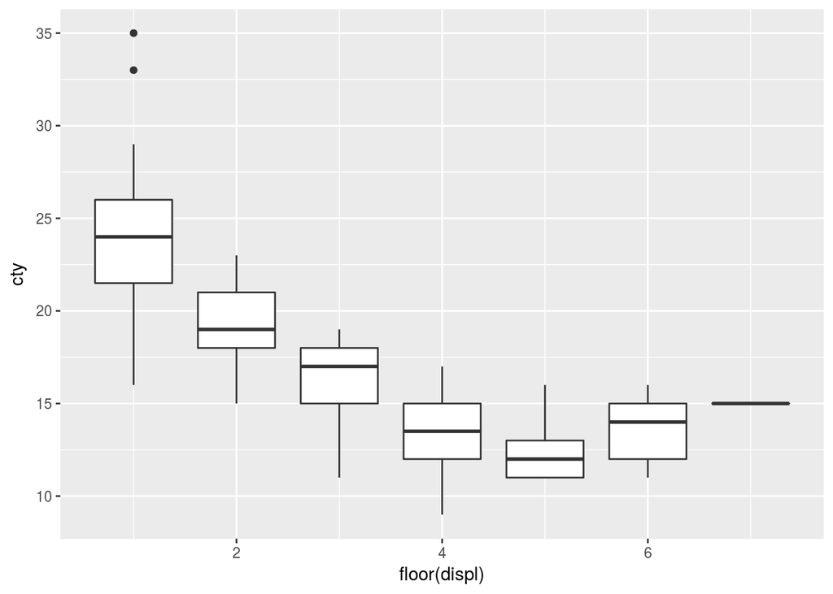

```r
ggplot(mpg, aes(floor(displ), cty,group=floor(displ))) + geom_boxplot()
```

3. When illustrating the difference between mapping continuous and discrete colors to a line, the discrete example needed `aes(group=1)`. Why? What happens if that is omitted? What’s the difference between `aes(group=1)` and `aes(group=2)`? Why?

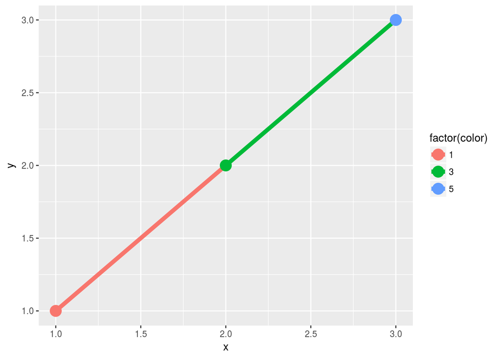

```r
df <- data.frame(x=1:3, y=1:3, color=c(1,3,5))

ggplot(df, aes(x,y,color=factor(color))) +
  geom_line(aes(group=1), size=2) +
  geom_point(size=5)
```

If it omitted, the points are drawn with no lines. Also, we get the following message: `Each group consists of only one observation. Do you need to adjust the group aesthetic?`

There is no change between the plots drawn with `aes(group=1)` and `aes(group=2)`. It doesn’t matter what integer value we use for group, the same picture is drawn.

4. How many bars are in each of the following plots? (Hint: try adding an outline around each bar with `color=white`)

3 bars:

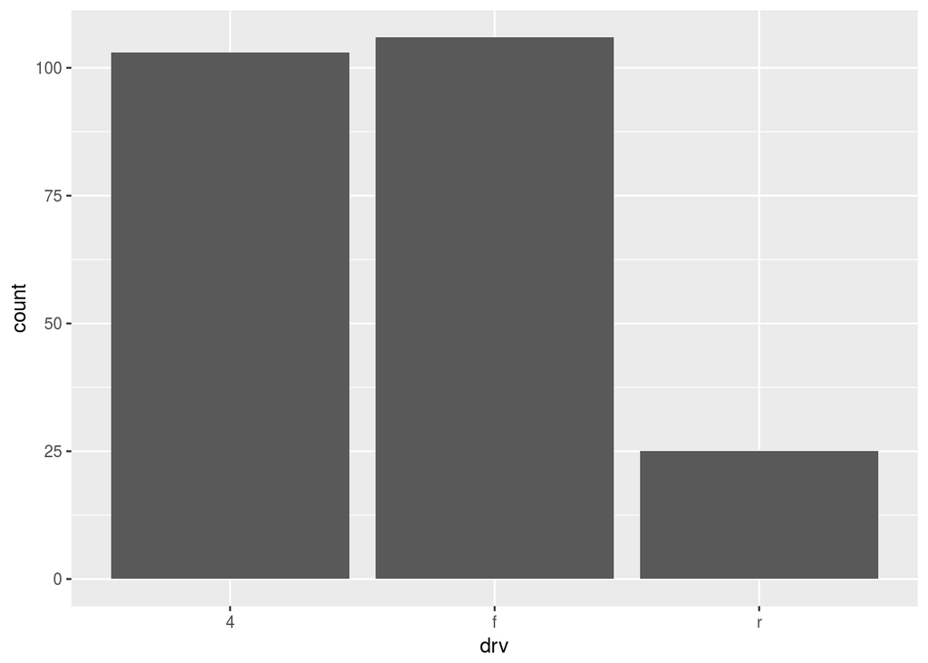

```r
ggplot(mpg, aes(drv),color="white") + geom_bar()
```

More bars than I’d like to count:

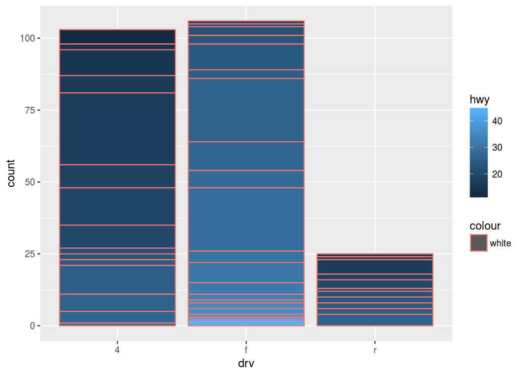

```r
ggplot(mpg, aes(drv, fill=hwy, group=hwy, color="white")) + geom_bar()
```

Even more bars:

```r
library(dplyr)
```

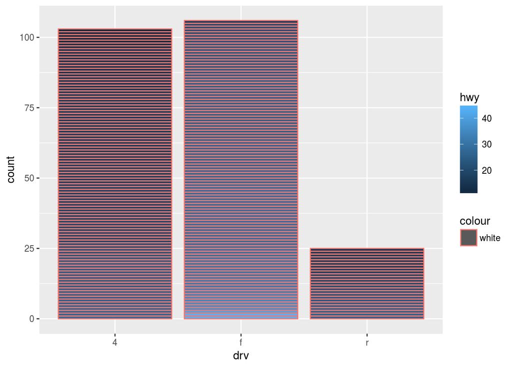

```r
mpg2 <- mpg %>% arrange(hwy) %>% mutate(id=seq_along(hwy))
ggplot(mpg2, aes(drv, fill=hwy, group=id, color="white")) + geom_bar()
```

5. Intsall the baby names package. It contains data about the popularity of babynames in the US. Run the following code and fix the resulting graph. Why does this graph make me unhappy?

Grouped by `sex` and used different color for each line.

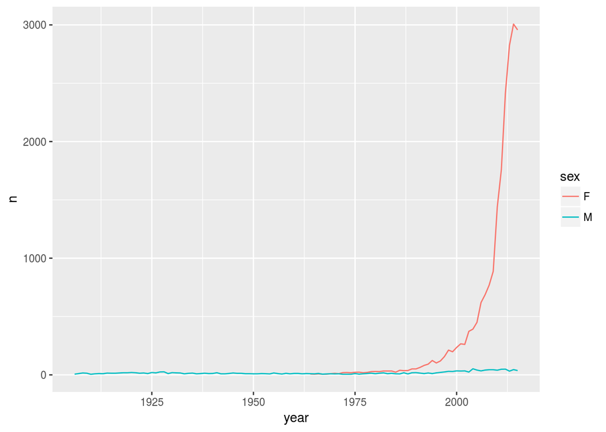

```r
#install.packages("babynames")
library(babynames)
hadley <- dplyr::filter(babynames, name=="Hadley")
ggplot(hadley, aes(year, n, group=sex, color=sex)) + geom_line()
```

# 3.11.1 Exercises

1. What binwidth tells you the most interesting story about the distribution of `caret`?

A binwidth of `1/12` is nice:

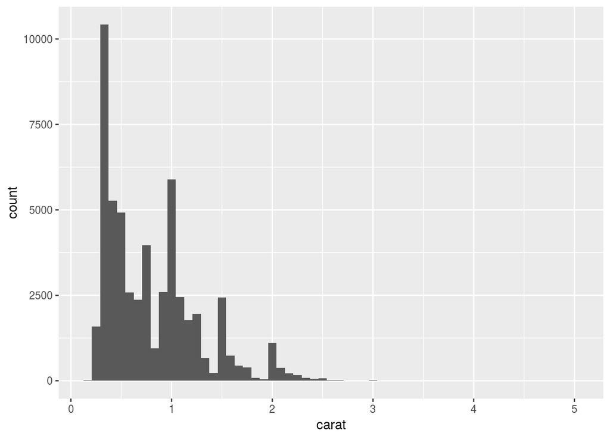

```r
ggplot(diamonds,aes(carat)) + geom_histogram(binwidth = 1/12)
```

2. Draw a histogram of `price`. What interesting patterns do you see?

Most diamonds are on the cheaper end. The distribution has a long tail to the right. It looks like it may be multimodal.

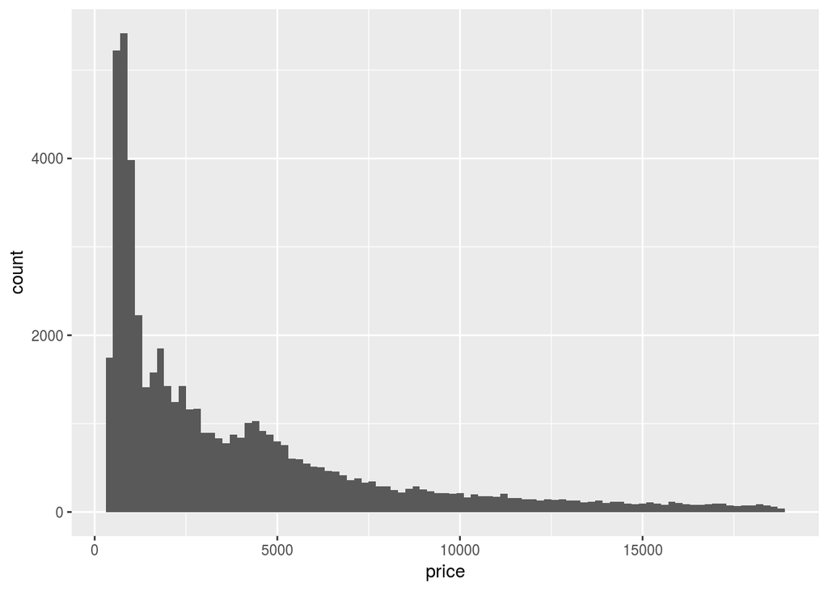

```r
ggplot(diamonds,aes(price)) + geom_histogram(binwidth = 200)
```

3. How does the distribution of `price` vary with `clarity`?

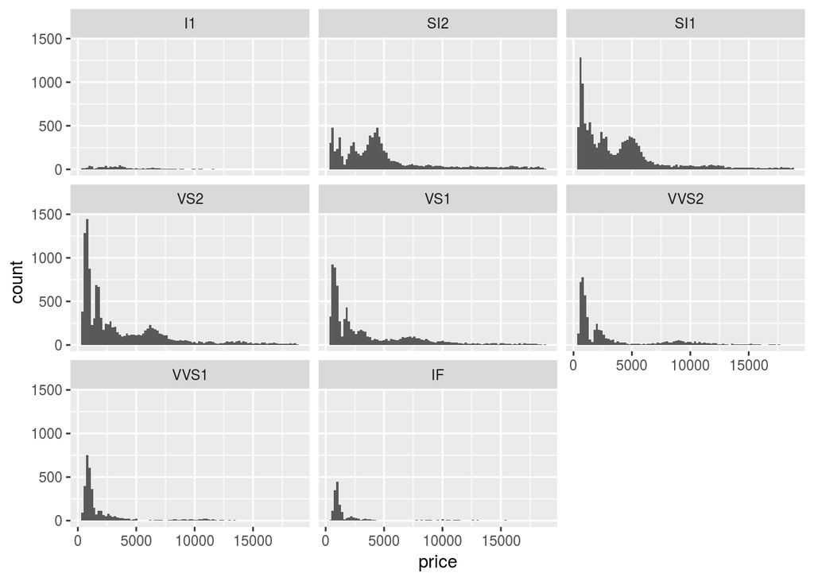

```r
ggplot(diamonds,aes(price)) + geom_histogram(binwidth = 200) + facet_wrap(~clarity)
```

4. Overlay a frequency polygon and density plot of `depth`. What computed variable do you need to map to `y` to make the two plots comparable? (You can either modify `geom_freqpoly()` or `geom_density()`.)

Jake Kaupp: " `geom_freqpoly` uses `y = ..count..` and `geom_density` uses `y = ..density..`. You can map different things to `y` in frequencypoly, so if you use an `aes(y = ..density..)` they become comparable."

Two solutions:

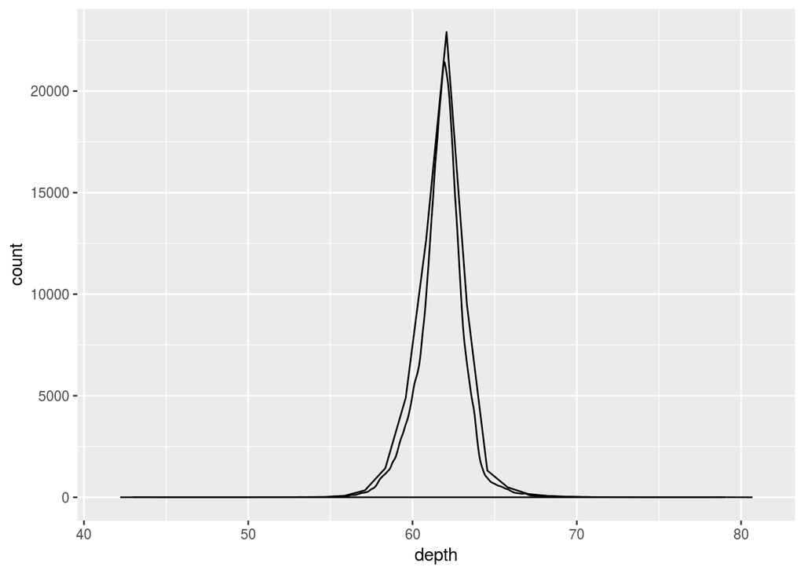

```r
ggplot(diamonds, aes(depth, ..count..)) + geom_freqpoly() + geom_density()
```

or…

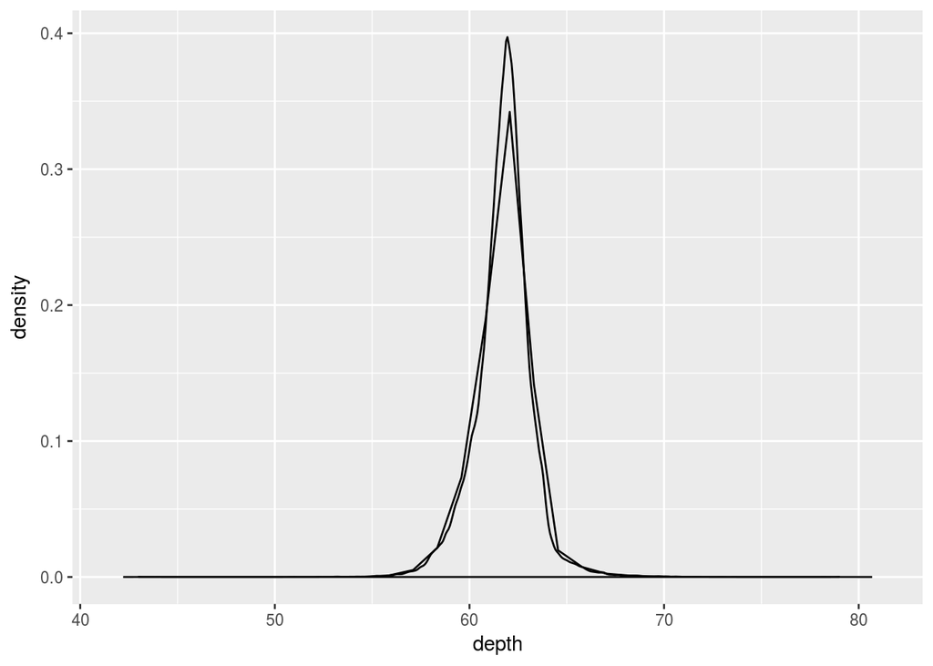

```r
ggplot(diamonds, aes(depth, ..density..)) + geom_freqpoly() + geom_density()
```